# Poder estadístico

Taller EGAP - Convivimos

Agosto 23, 2017

# Poder estadístico

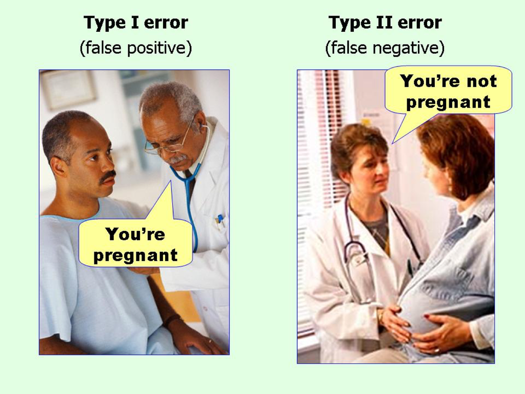

# ¿Qué es poder estdístico?

- La capacidad de nuestro experimento para detectar efectos estadísticamente significativos del tratamiento, si realmente existen.
- Capacidad del experimento de evitar un error de Tipo II (no rechazar equivocadamente la hipótesis nula de no efecto). ¿Ejemplo de embarazo?
- La probabilidad de estar en la región de rechazo de la hipótesis nula si la hipótesis alternativa es verdadera.

# Poder estadístico dentro de nuestras investigaciones

- El análisis de poder es algo que hacemos antes de realizar un estudio.
- **Objetivo:** descubrir si nuestro diseño planeado tiene el poder estadístico suficiente para detectar efectos si estos existen.
- Por lo general, planteamos una hipótesis sobre el efecto de tamaño de un tratamiento y comparamos esto con la hipótesis nula de ningún efecto.
- Tanto la hipótesis nula como la alternativa tienen distribuciones de muestreo asociadas que importan para el cálculo de poder.
- ¿Por qué no queremos un estudio con bajo poder? Es caro y difícil de interpretar

# ¿Cómo se ve el poder?

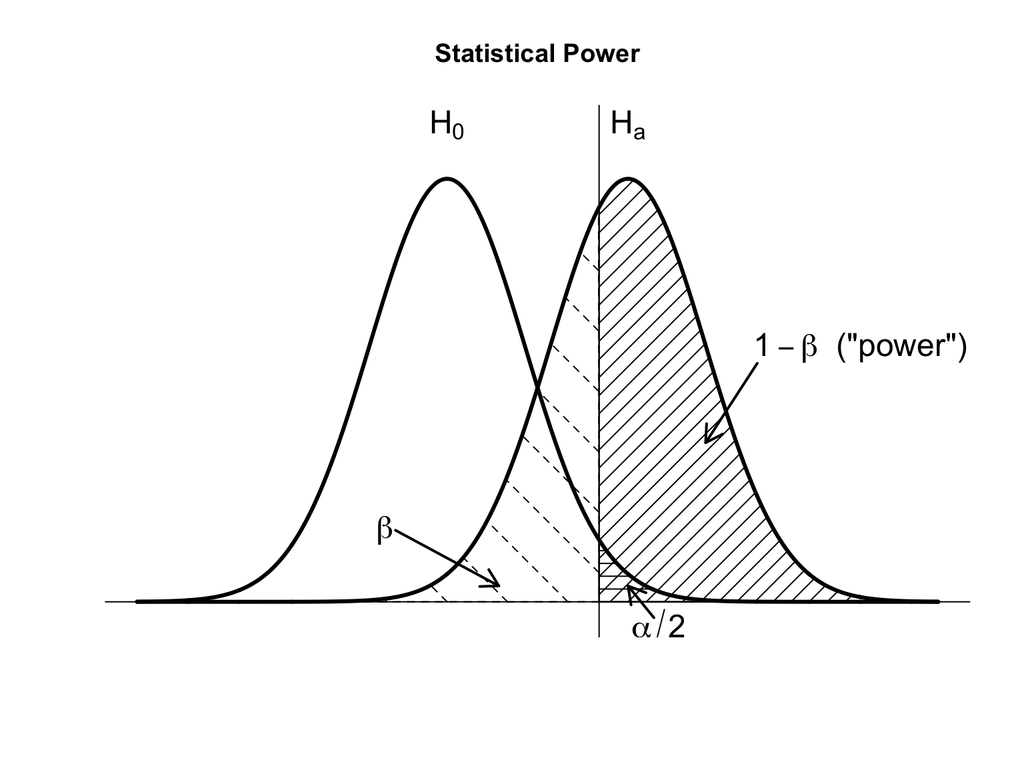

- Entonces… bajo la hipótesis nula, la distribución de nuestro ATE está centrado en $\mu_0$, y bajo la hipótesis alternativa, nuestro ATE se distribuye normal con media $\mu_1$
- Para un valor dado de $\mu_1$, el poder el la proporción de la distribución de $H1$ más allá del valor crítico (en una prueba de dos colas). $\beta$ en esta gráfica es la probabilidad de cometer error Tipo II.

# Análisis de poder simple: ¿Qué parámetros puedes variar?

- N
- Ruido de la variable de resultado (i.e., su varianza)
- Tamaño del efecto

# La fórmula analítica de poder

$$Poder = \Phi \bigg(\frac{\mid \mu_T - \mu_C \mid \sqrt{N}}{2\sigma} - \Phi^1(1 - \frac{\alpha}{2}) \bigg)$$

NOTA: Esta fórmula hace supuestos que aún no vamos a discutir

# La fórmula analítica de poder

$$Power = \Phi \bigg(\frac{\mid \mu_T - \mu_C \mid \sqrt{N}}{2\sigma} - \Phi^1(1 - \frac{\alpha}{2}) \bigg)$$

# Tamaño de la muestra

- Más observaciones $\rightarrow$ más poder
- Agregar más observaciones
- ¿Limitaciones?

# Veamos con una simulación cómo cambia el poder modificando algunos de estos parámetros.

```r
possible.ns <- seq(from = 100, to = 2000, by = 50)  # Los tamaños de la muestra que vamos a considerar
powers <- rep(NA, length(possible.ns))  # Objeto vació para guardar las estimaciones de las simulaciones
alpha <- 0.05  # Nivel de significancia estándar
sims <- 500  # Número de simulaciones para cada N

#### Loop externo para variar el número de sujetos ####
for (j in 1:length(possible.ns)) {
    N <- possible.ns[j]  # Tomar el valor j para N

    significant.experiments <- rep(NA, sims)  # Objeto vació para contar el número de experimentos significativos

    #### Loop interno para conducir experimentos 'sims' veces para
    #### cada valor de N ####
    for (i in 1:sims) {
        Y0 <- rnorm(n = N, mean = 60, sd = 20)  # Resultado potencial del control
        tau <- 5  # Efecto del tratamiento asumido
        Y1 <- Y0 + tau  # Resultado potencial del tratamiento
        Z.sim <- rbinom(n = N, size = 1, prob = 0.5)  # Hace asignación aleatoria
        Y.sim <- Y1 * Z.sim + Y0 * (1 - Z.sim)  # Resultados observados según asignación de tratemiento
        fit.sim <- lm(Y.sim ~ Z.sim)  # Análisis (regresión simple)
        p.value <- summary(fit.sim)$coefficients[2, 4]  # Extraer p-valores (asumimos igual varianza entre
        # grupos de control y tratamiento)
        significant.experiments[i] <- (p.value <= alpha)  # Determinar significancia según p <= 0.05
    }

    powers[j] <- mean(significant.experiments)  # almacenar tasa promedio de éxito (poder) para cada N
}
```

Veámos como se ve:

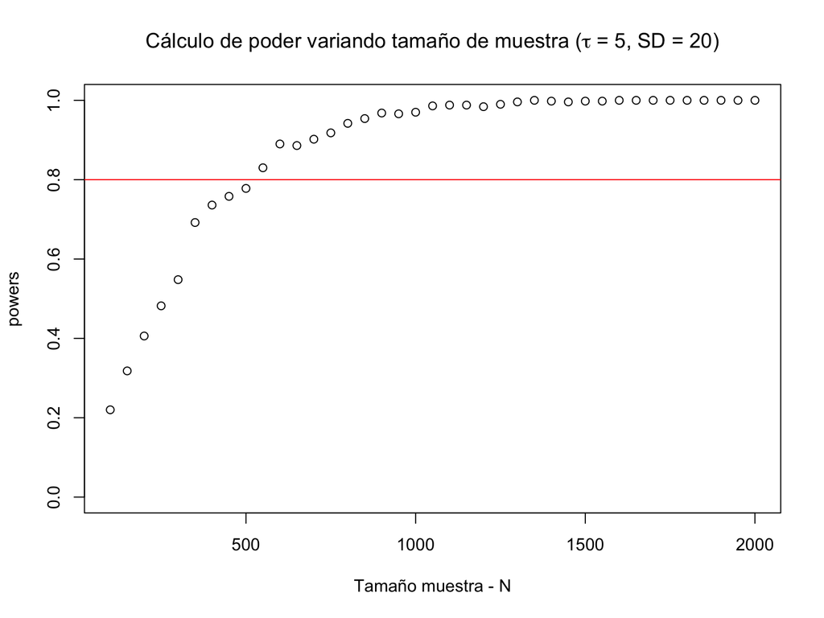

# Tamaño del efecto

- Tamaño más grande $\rightarrow$ más poder
- ¿Cómo?
  - Incrementar “dosificación”. Evitar tratamientos de bajo impacto
- ¿Limitaciones?

### Miremos qué pasa para diferentes tamaños del efecto

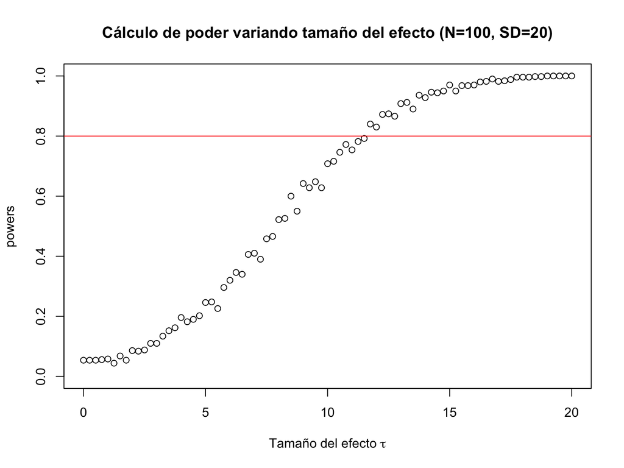

```r
possible.taus <- seq(from = 0, to = 20, by = 0.25)
powers <- rep(NA, length(possible.taus))
for (j in 1:length(possible.taus)) {
    N <- 100
    tau <- possible.taus[j]
    significant.experiments <- rep(NA, 500)
    for (i in 1:500) {
        Y0 <- rnorm(n = N, mean = 60, sd = 20)
        Y1 <- Y0 + tau
        Z.sim <- rbinom(n = N, size = 1, prob = 0.5)
        Y.sim <- Y1 * Z.sim + Y0 * (1 - Z.sim)
        fit.sim <- lm(Y.sim ~ Z.sim)
        p.value <- summary(fit.sim)$coefficients[2, 4]
        significant.experiments[i] <- (p.value <= 0.05)
    }
    powers[j] <- mean(significant.experiments)
}
plot(possible.taus, powers, ylim = c(0, 1), main = "Cálculo de poder variando tamaño del efecto (N=100, SD=20)",
    xlab = expression(paste("Tamaño del efecto ", tau)))
abline(h = 0.8, col = "red")
```

# Ruido de la variable de interés

- Menos ruido $\rightarrow$ más poder
- ¿Cómo?
  - Bloquear
  - Linea de base (Y y covariables)
  - Distintas medidas de su Y
- ¿Limitaciones?

### Miremos qué pasa con diferente ruido

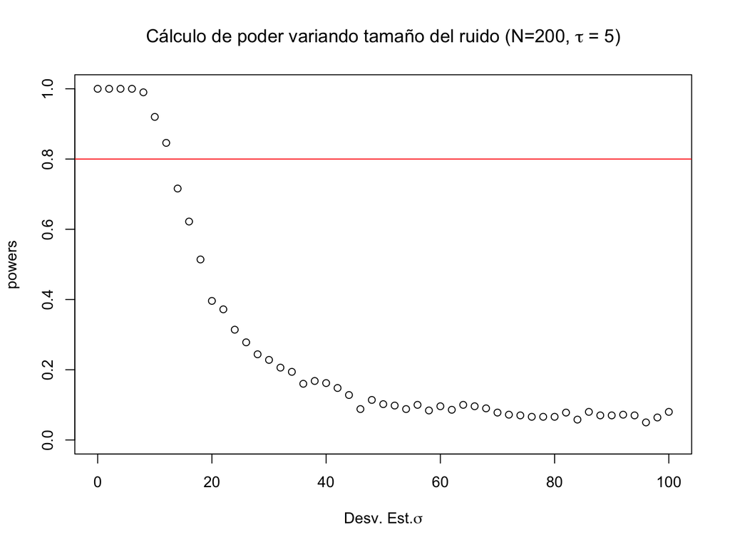

```r
possible.sds <- seq(from = 0, to = 100, by = 2)
powers <- rep(NA, length(possible.sds))
for (j in 1:length(possible.sds)) {
    N <- 200
    tau <- 5
    SDs <- possible.sds[j]
    significant.experiments <- rep(NA, 500)
    for (i in 1:500) {
        Y0 <- rnorm(n = N, mean = 60, sd = SDs)
        Y1 <- Y0 + tau
        Z.sim <- rbinom(n = N, size = 1, prob = 0.5)
        Y.sim <- Y1 * Z.sim + Y0 * (1 - Z.sim)
        fit.sim <- lm(Y.sim ~ Z.sim)
        p.value <- summary(fit.sim)$coefficients[2, 4]
        significant.experiments[i] <- (p.value <= 0.05)
    }
    powers[j] <- mean(significant.experiments)
}
plot(possible.sds, powers, ylim = c(0, 1), main = expression(paste("Cálculo de poder variando tamaño del ruido (N=200, ",
    tau, " = 5)")), xlab = expression(paste("Desv. Est.", sigma)))
abline(h = 0.8, col = "red")
```

# Análisis de poder para una aleatorización por clústeres

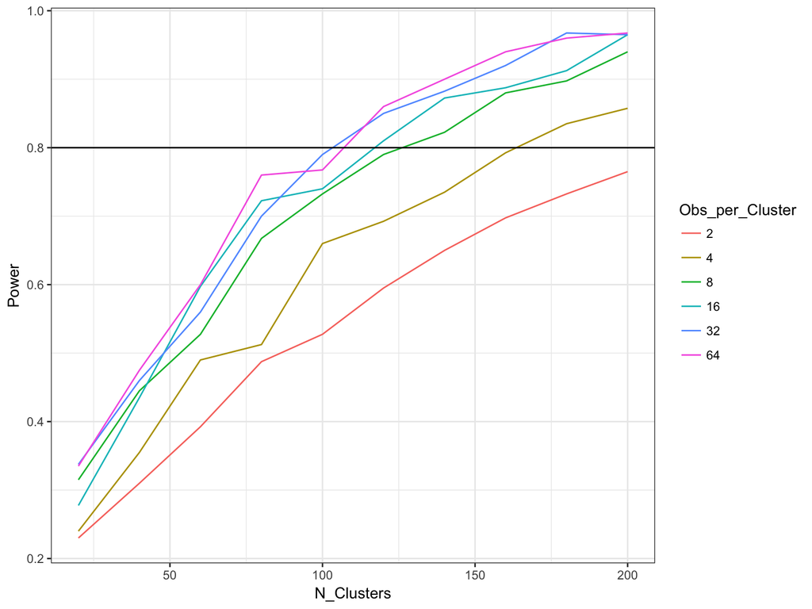